# Airline Passenger Satisfaction Analysis

## Preliminary Wrangling

This data set was obtained from [Kaggle](https://www.kaggle.com/johndddddd/customer-satisfaction/version/2?) and contains the results of a US airline satisfaction survey.

```python
# import all packages and set plots to be embedded inline
import numpy as np
import pandas as pd
import matplotlib.pyplot as plt
import seaborn as sb

%matplotlib inline
```

```python
# load data into a dataframe
sat_df = pd.read_csv('satisfaction_2015.csv')
```

View a little sample

```python
# View sample of 3 rows
sat_df.sample(3)
```

|  | id | satisfaction | gender | customer_type | age | type_of_travel | class | flight_distance | inflight_wifi_service | departure/arrival_time_convenient | ... | seat_comfort | inflight_entertainment | on-board_service | leg_room_service | baggage_handling | checkin_service | inflight_service | cleanliness | departure_delay_in_minutes | arrival_delay_in_minutes |
| --- | --- | --- | --- | --- | --- | --- | --- | --- | --- | --- | --- | --- | --- | --- | --- | --- | --- | --- | --- | --- | --- |
| 47802 | 71314 | neutral or dissatisfied | Male | disloyal Customer | 29 | Business travel | Business | 1514 | 2 | 2 | ... | 3 | 3 | 4 | 5 | 4 | 5 | 4 | 3 | 0 | 1 |
| 29598 | 18302 | neutral or dissatisfied | Female | Loyal Customer | 43 | Personal Travel | Business | 1024 | 3 | 5 | ... | 4 | 2 | 2 | 3 | 2 | 4 | 2 | 2 | 0 | 21 |
| 1776 | 84687 | neutral or dissatisfied | Female | Loyal Customer | 51 | Personal Travel | Eco | 2182 | 1 | 1 | ... | 3 | 4 | 4 | 2 | 4 | 4 | 4 | 3 | 0 | 2 |

3 rows × 24 columns

Some info about the datframe

```python
# Checking for column names, types, # of rows and nulls
sat_df.info()
```

```
<class 'pandas.core.frame.DataFrame'>
RangeIndex: 129880 entries, 0 to 129879
Data columns (total 24 columns):
 #   Column                             Non-Null Count   Dtype
---  ------                             --------------   -----
 0   id                                 129880 non-null  int64
 1   satisfaction                       129880 non-null  object
 2   gender                             129880 non-null  object
 3   customer_type                      129880 non-null  object
 4   age                                129880 non-null  int64
 5   type_of_travel                     129880 non-null  object
 6   class                              129880 non-null  object
 7   flight_distance                    129880 non-null  int64
 8   inflight_wifi_service              129880 non-null  int64
 9   departure/arrival_time_convenient  129880 non-null  int64
```

[output cut: 16 more lines]

```python
# Some statistics
sat_df.describe()
```

|  | id | age | flight_distance | inflight_wifi_service | departure/arrival_time_convenient | ease_of_online_booking | gate_location | food_and_drink | online_boarding | seat_comfort | inflight_entertainment | on-board_service | leg_room_service | baggage_handling | checkin_service | inflight_service | cleanliness | departure_delay_in_minutes | arrival_delay_in_minutes |
| --- | --- | --- | --- | --- | --- | --- | --- | --- | --- | --- | --- | --- | --- | --- | --- | --- | --- | --- | --- |
| count | 129880.000000 | 129880.000000 | 129880.000000 | 129880.000000 | 129880.000000 | 129880.000000 | 129880.000000 | 129880.000000 | 129880.000000 | 129880.000000 | 129880.000000 | 129880.000000 | 129880.000000 | 129880.000000 | 129880.000000 | 129880.000000 | 129880.000000 | 129880.000000 | 129880.000000 |
| mean | 64940.500000 | 39.427957 | 1190.316392 | 2.728696 | 3.057599 | 2.756876 | 2.976925 | 3.204774 | 3.252633 | 3.441361 | 3.358077 | 3.383023 | 3.350878 | 3.632114 | 3.306267 | 3.642193 | 3.286326 | 14.713713 | 15.045465 |
| std | 37493.270818 | 15.119360 | 997.452477 | 1.329340 | 1.526741 | 1.401740 | 1.278520 | 1.329933 | 1.350719 | 1.319289 | 1.334049 | 1.287099 | 1.316252 | 1.180025 | 1.266185 | 1.176669 | 1.313682 | 38.071126 | 38.416353 |
| min | 1.000000 | 7.000000 | 31.000000 | 0.000000 | 0.000000 | 0.000000 | 0.000000 | 0.000000 | 0.000000 | 0.000000 | 0.000000 | 0.000000 | 0.000000 | 1.000000 | 0.000000 | 0.000000 | 0.000000 | 0.000000 | 0.000000 |
| 25% | 32470.750000 | 27.000000 | 414.000000 | 2.000000 | 2.000000 | 2.000000 | 2.000000 | 2.000000 | 2.000000 | 2.000000 | 2.000000 | 2.000000 | 2.000000 | 3.000000 | 3.000000 | 3.000000 | 2.000000 | 0.000000 | 0.000000 |
| 50% | 64940.500000 | 40.000000 | 844.000000 | 3.000000 | 3.000000 | 3.000000 | 3.000000 | 3.000000 | 3.000000 | 4.000000 | 4.000000 | 4.000000 | 4.000000 | 4.000000 | 3.000000 | 4.000000 | 3.000000 | 0.000000 | 0.000000 |
| 75% | 97410.250000 | 51.000000 | 1744.000000 | 4.000000 | 4.000000 | 4.000000 | 4.000000 | 4.000000 | 4.000000 | 5.000000 | 4.000000 | 4.000000 | 4.000000 | 5.000000 | 4.000000 | 5.000000 | 4.000000 | 12.000000 | 13.000000 |
| max | 129880.000000 | 85.000000 | 4983.000000 | 5.000000 | 5.000000 | 5.000000 | 5.000000 | 5.000000 | 5.000000 | 5.000000 | 5.000000 | 5.000000 | 5.000000 | 5.000000 | 5.000000 | 5.000000 | 5.000000 | 1592.000000 | 1584.000000 |

### What is the structure of your dataset?

The dataframe contains 24 columns and 129880. 5 columns are string and the rest are integers.

### What is/are the main feature(s) of interest in your dataset?

The main feature is the overall `satisfaction` which takes the value of "satisfied" and "neutral or dissatisfied".

### What features in the dataset do you think will help support your investigation into your feature(s) of interest?

I am interested in seing the impact travel distance, class and delays has on the satisfaction, another interesting feature to investigate is the age. I don't expect a very strong relation between a specific satisfaction factors and the overall satisfaction since I think they only affect in extreme cases.

## Univariate Exploration

Let's start by checking the distribution of our main feature `satisfaction`:

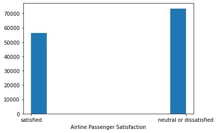

```python
# plot satisfaction
plt.hist(sat_df['satisfaction'])
plt.xlabel('Airline Passenger Satisfaction');
```

Seems we have more customers that are either neutral or dissatisfied.

Now for the age:

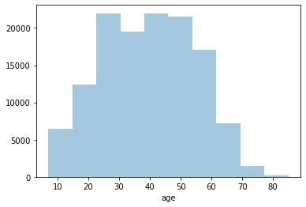

```python
# Plot age
sb.distplot(sat_df.age,bins=10,kde=False);
```

We got a normal distribution with most of the people being adults between 30 and 50 years

Let's check the flight distance:

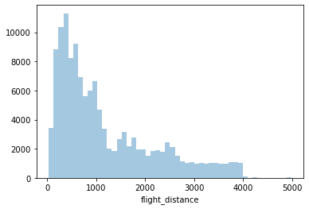

```python
# Plot flight distance
sb.distplot(sat_df['flight_distance'],kde=False);
```

Most of the flights are under 1000 miles

Let's check the class:

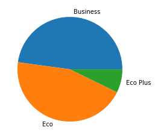

```python
# Plot class distribution
plt.pie(sat_df['class'].value_counts(),labels=['Business','Eco','Eco Plus']);
```

We have slightly more Business flights than Economic.

Next, we will take a look at the most common type of travel:

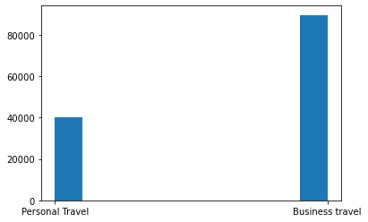

```python
# Plot type of travel
plt.hist(sat_df['type_of_travel']);
```

There is a proportion of 2 to 1 when comparing business to personal travel

Looking at these features I am getting the idea that the surveyed customers are business people on short trips and they don't seem to be very satisfied

Next, let's investigate the additional satisfaction factors:

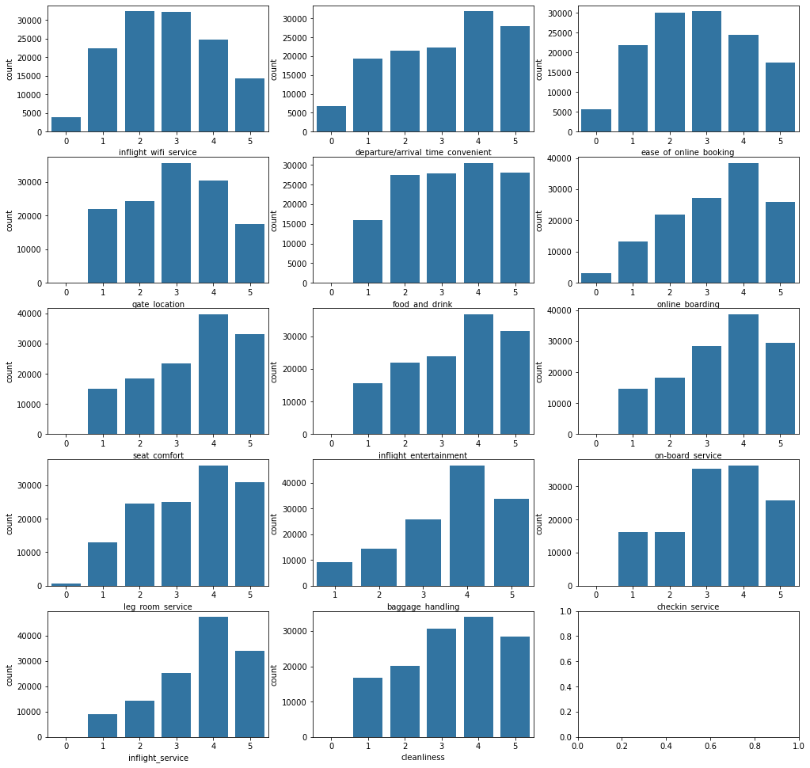

```python
# Plot grid with distributions of additional satisfaction factors
fig, ax = plt.subplots(nrows=5, ncols = 3,figsize = [17,17])

default_color = sb.color_palette()[0]

sb.countplot(data = sat_df, x = 'inflight_wifi_service', color = default_color, ax = ax[0,0])
sb.countplot(data = sat_df, x = 'departure/arrival_time_convenient', color = default_color, ax = ax[0,1])
sb.countplot(data = sat_df, x = 'ease_of_online_booking', color = default_color, ax = ax[0,2])
sb.countplot(data = sat_df, x = 'gate_location', color = default_color, ax = ax[1,0])
sb.countplot(data = sat_df, x = 'food_and_drink', color = default_color, ax = ax[1,1])
sb.countplot(data = sat_df, x = 'online_boarding', color = default_color, ax = ax[1,2])
sb.countplot(data = sat_df, x = 'seat_comfort', color = default_color, ax = ax[2,0])
sb.countplot(data = sat_df, x = 'inflight_entertainment', color = default_color, ax = ax[2,1])
sb.countplot(data = sat_df, x = 'on-board_service', color = default_color, ax = ax[2,2])
sb.countplot(data = sat_df, x = 'leg_room_service', color = default_color, ax = ax[3,0])
sb.countplot(data = sat_df, x = 'baggage_handling', color = default_color, ax = ax[3,1])
sb.countplot(data = sat_df, x = 'checkin_service', color = default_color, ax = ax[3,2])
sb.countplot(data = sat_df, x = 'inflight_service', color = default_color, ax = ax[4,0])
sb.countplot(data = sat_df, x = 'cleanliness', color = default_color, ax = ax[4,1]);
```

Good satisfaction for most of them except inflight wifi service, ease of online booking and gate location

### Discuss the distribution(s) of your variable(s) of interest. Were there any unusual points? Did you need to perform any transformations?

Nothing unusual, just more neutral and dissatisfied customers, I will need to change the values to 1 and 0 to come up with averages and continue the investigation.

### Of the features you investigated, were there any unusual distributions? Did you perform any operations on the data to tidy, adjust, or change the form of the data? If so, why did you do this?

For the flight distance we have some outliers with high values but it's clear that the distribution is leaning towars short flights.

## Bivariate Exploration

For our Bivariate Exploration, let's check the relation between satisfaction and some of the other features, but first, I will change the column values of satisfaction to a numeric value in order to calculate the average satisfaction

```python
# Replace values in satisfaction column
sat_df['satisfaction'].replace(['satisfied','neutral or dissatisfied'],[1,0],inplace=True)
```

So now we have a numeric value that we can use in our exploration, first let's plot the satisfaction by age:

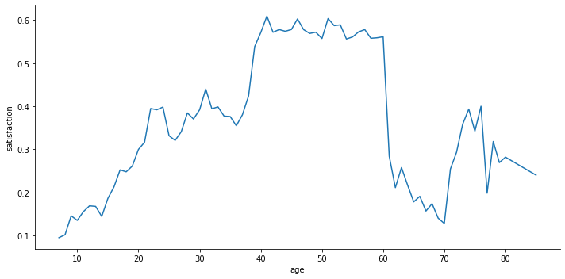

```python
# Plot satisfaction by age
sb.relplot(x="age", y="satisfaction",ci=None, kind="line",aspect=2, data=sat_df);
```

It seems the satisfaction increases as age goes up to 40 years then stabilizes until 60 then drops a lot after 60 with a small spike between 70 and 80.

Let's check satisfaction by Gender:

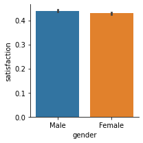

```python
# plot satisfaction by gender
sb.catplot(x='gender',y='satisfaction', kind='bar',height=3,data=sat_df);
```

It's almost the same satisfaction so gender does not seem to have a lot of influence in the satisfaction

Next, we will view satisfaction by class:

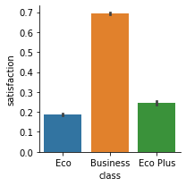

```python
# plot satisfaction by class
sb.catplot(x='class',y='satisfaction', kind='bar',height=3,data=sat_df);
```

There seems to be a big difference in satisfaction for passengers that travel on the business class vs the ones that travel on economic, I think this could be one of the main factors that influence satisfaction since the class encompasses other things such as food, in-fligh services, leg room, etc.

Now, the satisfaction for each travel type:

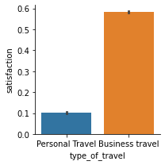

```python
# plot satisfaction by travel type
sb.catplot(x='type_of_travel',y='satisfaction', kind='bar',height=3,data=sat_df);
```

Wow, the satisfaction for people traveling for personal reasons is very low at 10%, I am interested in seeing in which class they are traveling:

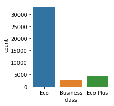

```python
# Plot travel class for personal travel
sb.catplot(x='class', kind='count',height=3,data=sat_df.query('type_of_travel == "Personal Travel"'));
```

Ok, so most of them travel in Economic class, the low satisfaction makes sense since people traveling in economic have a lower satisfaction percentage.

Let's check the class for people on business travel:

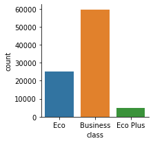

```python
# Plot travel class for business travel
sb.catplot(x='class', kind='count',height=3,data=sat_df.query('type_of_travel == "Business travel"'));
```

So most people that travels for business reasons uses business class and it is possible that for that reason they have higher satisfaction. I am going to explore the additional satisfaction factors filtered by class (Business vs Economic).

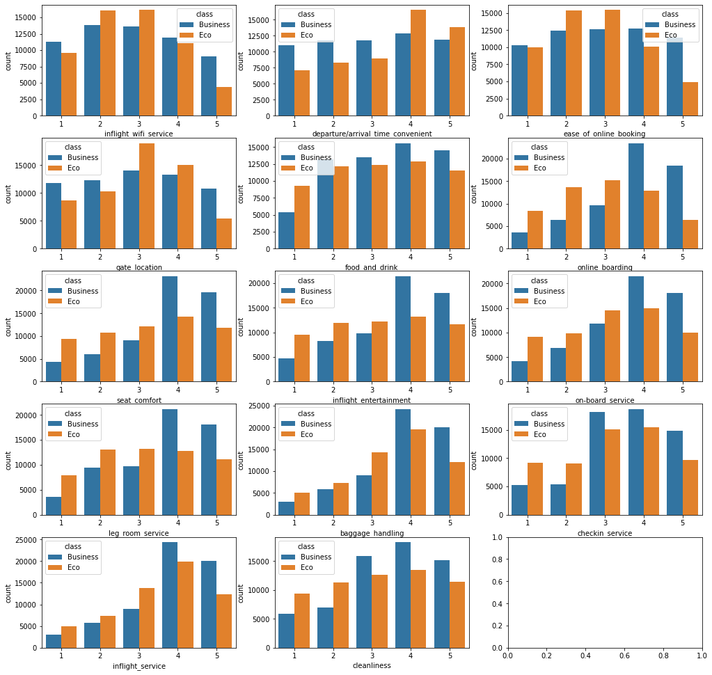

```python
#plot aditional satisfaction factors by class
fig, ax = plt.subplots(nrows=5, ncols = 3,figsize = [17,17])

default_color = sb.color_palette()[0]

sb.countplot(data = sat_df, hue='class', hue_order=['Business','Eco'],x = 'inflight_wifi_service', ax = ax[0,0],order=[1,2,3,4,5])
sb.countplot(data = sat_df, hue='class', hue_order=['Business','Eco'],x = 'departure/arrival_time_convenient', ax = ax[0,1],order=[1,2,3,4,5])
sb.countplot(data = sat_df, hue='class', hue_order=['Business','Eco'],x = 'ease_of_online_booking', ax = ax[0,2],order=[1,2,3,4,5])
sb.countplot(data = sat_df, hue='class', hue_order=['Business','Eco'],x = 'gate_location', ax = ax[1,0],order=[1,2,3,4,5])
sb.countplot(data = sat_df, hue='class', hue_order=['Business','Eco'],x = 'food_and_drink', ax = ax[1,1],order=[1,2,3,4,5])
sb.countplot(data = sat_df, hue='class', hue_order=['Business','Eco'],x = 'online_boarding', ax = ax[1,2],order=[1,2,3,4,5])
sb.countplot(data = sat_df, hue='class', hue_order=['Business','Eco'],x = 'seat_comfort', ax = ax[2,0],order=[1,2,3,4,5])
sb.countplot(data = sat_df, hue='class', hue_order=['Business','Eco'],x = 'inflight_entertainment',ax = ax[2,1],order=[1,2,3,4,5])
sb.countplot(data = sat_df, hue='class', hue_order=['Business','Eco'],x = 'on-board_service', ax = ax[2,2],order=[1,2,3,4,5])
sb.countplot(data = sat_df, hue='class', hue_order=['Business','Eco'],x = 'leg_room_service', ax = ax[3,0],order=[1,2,3,4,5])
sb.countplot(data = sat_df, hue='class', hue_order=['Business','Eco'],x = 'baggage_handling', ax = ax[3,1],order=[1,2,3,4,5])
sb.countplot(data = sat_df, hue='class', hue_order=['Business','Eco'],x = 'checkin_service',  ax = ax[3,2],order=[1,2,3,4,5])
sb.countplot(data = sat_df, hue='class', hue_order=['Business','Eco'],x = 'inflight_service', ax = ax[4,0],order=[1,2,3,4,5])
sb.countplot(data = sat_df, hue='class', hue_order=['Business','Eco'],x = 'cleanliness',  ax = ax[4,1],order=[1,2,3,4,5]);
```

Looking at the distribution of survey results by class, the columns that stand out as being better qualified in business class are:

- online_boarding
- seat_comfort
- inflight_entertainment
- on-board_service
- leg_room_service

### Talk about some of the relationships you observed in this part of the investigation. How did the feature(s) of interest vary with other features in the dataset?

Class seems to be a feature that is closely related to the satisfaction, age also has an interesting relationship, gender does not seem to matter.

### Did you observe any interesting relationships between the other features (not the main feature(s) of interest)?

For each class there are some important additional factors that create satisfaction/dissatisfaction, so you can relate dissatisfaction in certain features with a economic class for example.

## Multivariate Exploration

Let's see if there are additional relation by comparing more features. First we will try with age, satisfaction and class together:

[figure not shown]

```python
# plot satisfaction by age and class
sb.relplot(x="age", y="satisfaction",ci=None, kind="line",hue='class',aspect=2, data=sat_df);
```

We see a clear difference with the class where for all ages there is lower satisfaction.

Now, we will check with travel type:

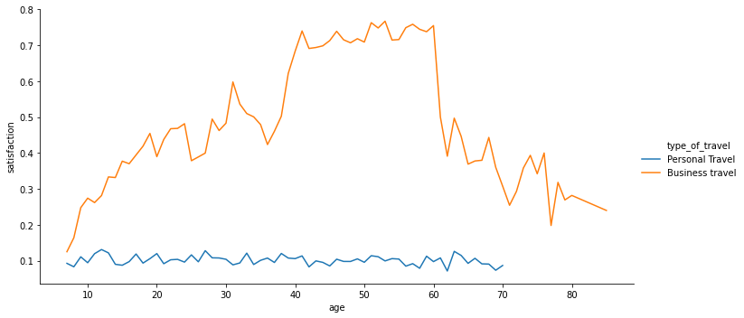

```python
# plot satisfaction by age and travel type
sb.relplot(x="age", y="satisfaction",ci=None, kind="line",hue='type_of_travel',aspect=2, data=sat_df);
```

Dissatisfaction is very similar for all ages when the passenger travels for personal reasons, this is in part explained by the high amount of people that uses economic class for that type of travel.

One of the additional factors I was interested in researching was the leg room, I will plot the satisfaction by leg room survey result, also split by class:

[figure not shown]

```python
# plot satisfaction by leg room survey result split by class
sb.barplot(data = sat_df, hue='class', hue_order=['Business','Eco'],x ='leg_room_service',y='satisfaction',order=[1,2,3,4,5]);
```

Note that I am not including the 0 value since for what I have been exploring it was used as a N/A value. The plot shows that not much improved in satisfaction for customers that are happy with the leg room, let's try with gate location since it also showed negative results for economic class passengers:

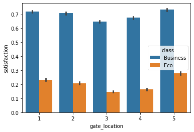

```python
# plot satisfaction by gate location survey result split by class
sb.barplot(data = sat_df, hue='class', hue_order=['Business','Eco'],x ='gate_location',y='satisfaction',order=[1,2,3,4,5]);
```

This time, customers with a good satisfaction on gate location showed a higher overall satisfaction but also the ones with low results showed improved overall satisfaction. This does note seem to be a decisive factor for the overall satisfaction.

Let's try one more which will be inflight wifi service:

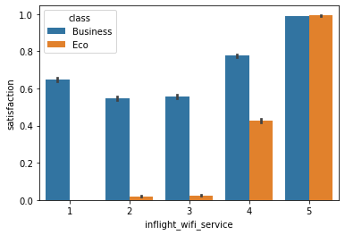

```python
# plot satisfaction by inflight wifi service survey result split by class
sb.barplot(data = sat_df, hue='class', hue_order=['Business','Eco'],x ='inflight_wifi_service',y='satisfaction',order=[1,2,3,4,5]);
```

Now this is something I did not expect, passengers that gave a satisfied response for the inflight wifi service also had a great overall satisfaction (at or almost 100%). I think that if this is because a bad connection can be very frustrating.

### Talk about some of the relationships you observed in this part of the investigation. Were there features that strengthened each other in terms of looking at your feature(s) of interest?

No, I was expecting more of the additional satisfaction factors to be related with the overall satisfaction but they don't have enough weight in the final decision.

### Were there any interesting or surprising interactions between features?

Yes, I was surprised by the satisfaction results of customers that gave a good survey for inflight wifi service.